# Data Analysis of the Pima Indians Diabetes Dataset using Regressions in R - Self study

Fernando Guntoro and Sonja Tang

2022-11-13

**Objective**: The objective of this tutorial is to investigate risk factors that are associated with diabetes in the Pima Indians Diabetes dataset using regressions.

We will put into practice basic data cleaning, linear and logistic regressions, data visualization and interpretation.

**Dataset**: The Pima dataset is made up of survey results from a study conducted by the National Institute of Diabetes and Digestive and Kidney Diseases on female Pima Indians living near Phoenix.

Firstly, let’s set up the library and load the Pima dataset from the “faraway” R package.

```r
list.of.packages <- c("faraway", "viridis", "tidyverse", "corrplot")
new.packages <- list.of.packages[!(list.of.packages %in% installed.packages()[,"Package"])]
if(length(new.packages)) install.packages(new.packages)

library(faraway)
library(viridis)
library(tidyverse)
library(corrplot)
data(pima)
```

## Basic exploration of the data

*What are some basic data types in R?*

Let’s first look at the dimensions and types of variables we have in our dataset. There are many ways to do this:

### str

```r
str(pima)
```

```
## 'data.frame':    768 obs. of  9 variables:
##  $ pregnant : int  6 1 8 1 0 5 3 10 2 8 ...
##  $ glucose  : int  148 85 183 89 137 116 78 115 197 125 ...
##  $ diastolic: int  72 66 64 66 40 74 50 0 70 96 ...
##  $ triceps  : int  35 29 0 23 35 0 32 0 45 0 ...
##  $ insulin  : int  0 0 0 94 168 0 88 0 543 0 ...
##  $ bmi      : num  33.6 26.6 23.3 28.1 43.1 25.6 31 35.3 30.5 0 ...
##  $ diabetes : num  0.627 0.351 0.672 0.167 2.288 ...
##  $ age      : int  50 31 32 21 33 30 26 29 53 54 ...
##  $ test     : int  1 0 1 0 1 0 1 0 1 1 ...
```

### dim

```r
dim(pima)
```

```
## [1] 768   9
```

### head

```r
head(pima)
```

|  | pregnant | glucose | diastolic | triceps | insulin | bmi | diabetes | age | test |
| --- | --- | --- | --- | --- | --- | --- | --- | --- | --- |
| 1 | 6 | 148 | 72 | 35 | 0 | 33.6 | 0.627 | 50 | 1 |
| 2 | 1 | 85 | 66 | 29 | 0 | 26.6 | 0.351 | 31 | 0 |
| 3 | 8 | 183 | 64 | 0 | 0 | 23.3 | 0.672 | 32 | 1 |
| 4 | 1 | 89 | 66 | 23 | 94 | 28.1 | 0.167 | 21 | 0 |
| 5 | 0 | 137 | 40 | 35 | 168 | 43.1 | 2.288 | 33 | 1 |
| 6 | 5 | 116 | 74 | 0 | 0 | 25.6 | 0.201 | 30 | 0 |

### tail

```r
tail(pima)
```

|  | pregnant | glucose | diastolic | triceps | insulin | bmi | diabetes | age | test |
| --- | --- | --- | --- | --- | --- | --- | --- | --- | --- |
| 763 | 9 | 89 | 62 | 0 | 0 | 22.5 | 0.142 | 33 | 0 |
| 764 | 10 | 101 | 76 | 48 | 180 | 32.9 | 0.171 | 63 | 0 |
| 765 | 2 | 122 | 70 | 27 | 0 | 36.8 | 0.340 | 27 | 0 |
| 766 | 5 | 121 | 72 | 23 | 112 | 26.2 | 0.245 | 30 | 0 |
| 767 | 1 | 126 | 60 | 0 | 0 | 30.1 | 0.349 | 47 | 1 |
| 768 | 1 | 93 | 70 | 31 | 0 | 30.4 | 0.315 | 23 | 0 |

### summary

```r
summary(pima)
```

```
##     pregnant         glucose        diastolic         triceps
##  Min.   : 0.000   Min.   :  0.0   Min.   :  0.00   Min.   : 0.00
##  1st Qu.: 1.000   1st Qu.: 99.0   1st Qu.: 62.00   1st Qu.: 0.00
##  Median : 3.000   Median :117.0   Median : 72.00   Median :23.00
##  Mean   : 3.845   Mean   :120.9   Mean   : 69.11   Mean   :20.54
##  3rd Qu.: 6.000   3rd Qu.:140.2   3rd Qu.: 80.00   3rd Qu.:32.00
##  Max.   :17.000   Max.   :199.0   Max.   :122.00   Max.   :99.00
##     insulin           bmi           diabetes           age
##  Min.   :  0.0   Min.   : 0.00   Min.   :0.0780   Min.   :21.00
##  1st Qu.:  0.0   1st Qu.:27.30   1st Qu.:0.2437   1st Qu.:24.00
##  Median : 30.5   Median :32.00   Median :0.3725   Median :29.00
##  Mean   : 79.8   Mean   :31.99   Mean   :0.4719   Mean   :33.24
##  3rd Qu.:127.2   3rd Qu.:36.60   3rd Qu.:0.6262   3rd Qu.:41.00
##  Max.   :846.0   Max.   :67.10   Max.   :2.4200   Max.   :81.00
##       test
##  Min.   :0.000
##  1st Qu.:0.000
##  Median :0.000
##  Mean   :0.349
##  3rd Qu.:1.000
##  Max.   :1.000
```

There are 768 individuals in the study, and 9 variables were recorded. It may be useful to categorize glucose and insulin into factors, based on some medical background (mayoclinic.org and medscape).

```r
pima$test <- factor(pima$test)

pima$glucose_cat <- factor(ifelse(pima$glucose <= 140, "Normal",
                           ifelse(pima$glucose <= 200, "Medium", "High")))
pima$insulin_cat <- factor(ifelse(pima$insulin <= 16, "Low",
                           ifelse(pima$glucose <= 166, "Normal", "High")))
summary(pima[,9:11])
```

```
##  test    glucose_cat  insulin_cat
##  0:500   Medium:192   High  : 44
##  1:268   Normal:576   Low   :377
##                       Normal:347
```

## Exploratory data analysis

*What are some useful types of plots for visualizing data?*

Let’s look at these variables in more depth by plotting a simple histogram to visualize their distributions. We can do this with base R easily, and also using ggplot.

### Base R

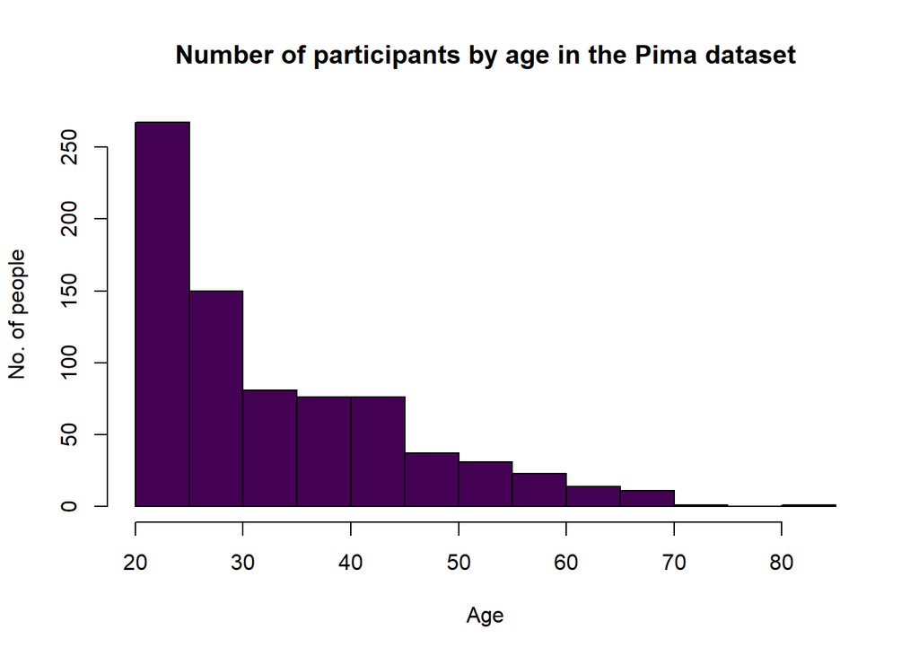

```r
hist(pima$age,
     main="Number of participants by age in the Pima dataset",
  xlab="Age",
  ylab="No. of people",
  col=viridis(1)
)
```

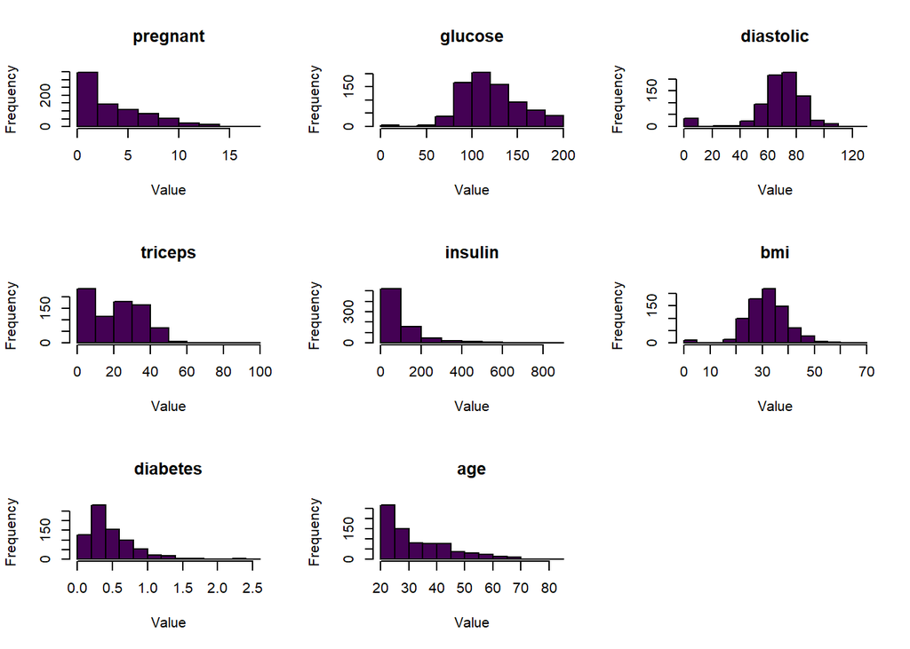

```r
# Often we may want to visualize the variables altogether
par(mfrow =c(3,3))
for (i in seq(8)) {
  hist(pima[,i],
     main=names(pima)[i],
  xlab="Value",
  ylab="Frequency",
  col=viridis(1)
  )
}
par(mfrow =c(1,1))
```

### ggplot

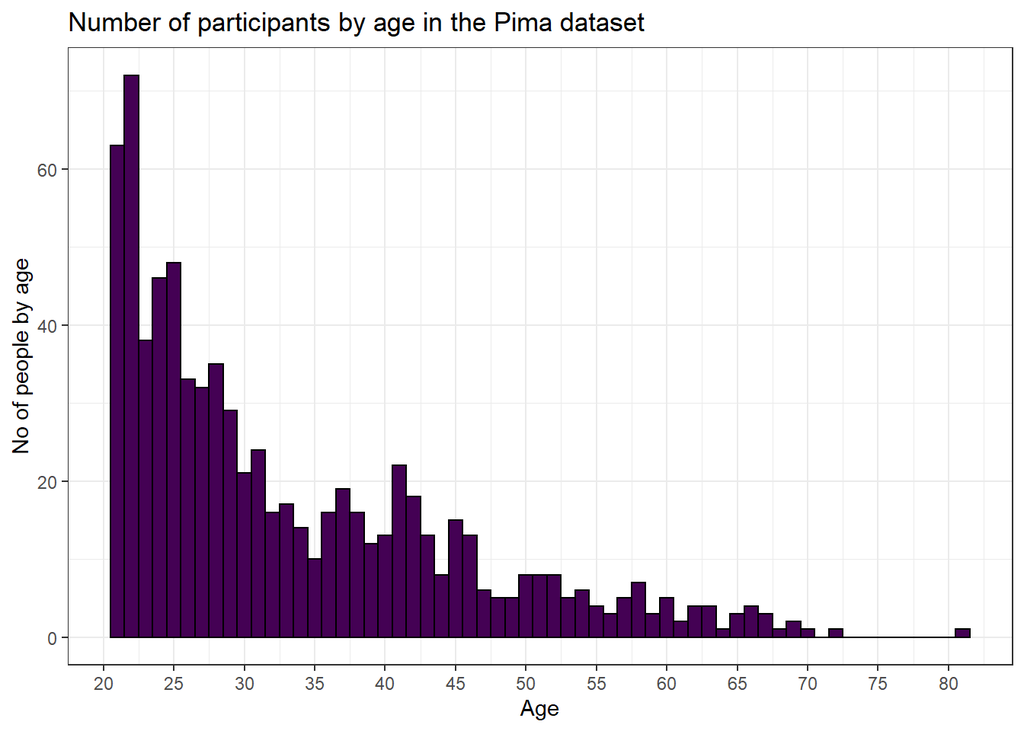

```r
ggplot(pima, aes(x = age)) +
  geom_histogram(binwidth = 1, color = "black", fill = viridis(1)) +
  scale_x_continuous(breaks=seq(20,90,5)) +
  ggtitle("Number of participants by age in the Pima dataset") +
  xlab("Age") +
  ylab("No of people by age") +
  theme_bw()
```

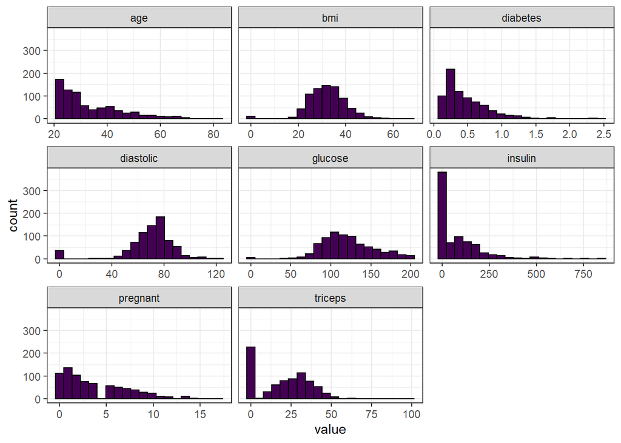

```r
ggplot(gather(pima[,1:8]), aes(value)) +
    geom_histogram(bins = 20, color = "black", fill = viridis(1)) +
    theme_bw() +
    facet_wrap(~key, scales = 'free_x')
```

## {.unlisted .unnumbered}

## Further quality control check

Let’s check if these variables contain any NA value, we may want to remove or impute them.

```r
colSums(is.na(pima)) # Check if each column contains NA values
```

```
##    pregnant     glucose   diastolic     triceps     insulin         bmi
##           0           0           0           0           0           0
##    diabetes         age        test glucose_cat insulin_cat
##           0           0           0           0           0
```

No NAs, but this was a trick question. **Notice the zeros!**

```r
pima_na <- pima
pima_na$bmi[pima$bmi == 0] <- NA
pima_na$diastolic[pima$diastolic == 0] <- NA
pima_na$glucose[pima$glucose == 0] <- NA
pima_na$insulin[pima$insulin == 0] <- NA
pima_na$triceps[pima$triceps == 0] <- NA

pima_na <- na.omit(pima_na) # remove all observations containing NA values
```

Now that we have removed the NAs, let’s visualize the distributions again.

### Base R plot

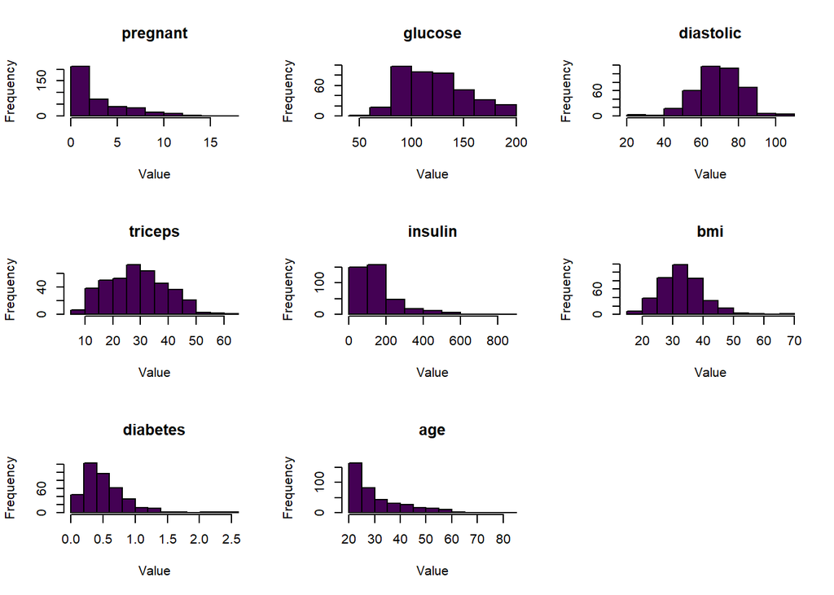

```r
par(mfrow =c(3,3))
for (i in seq(8)) {
  hist(pima_na[,i],
     main=names(pima)[i],
  xlab="Value",
  ylab="Frequency",
  col=viridis(1)
  )
}
par(mfrow =c(1,1))
```

### ggplot

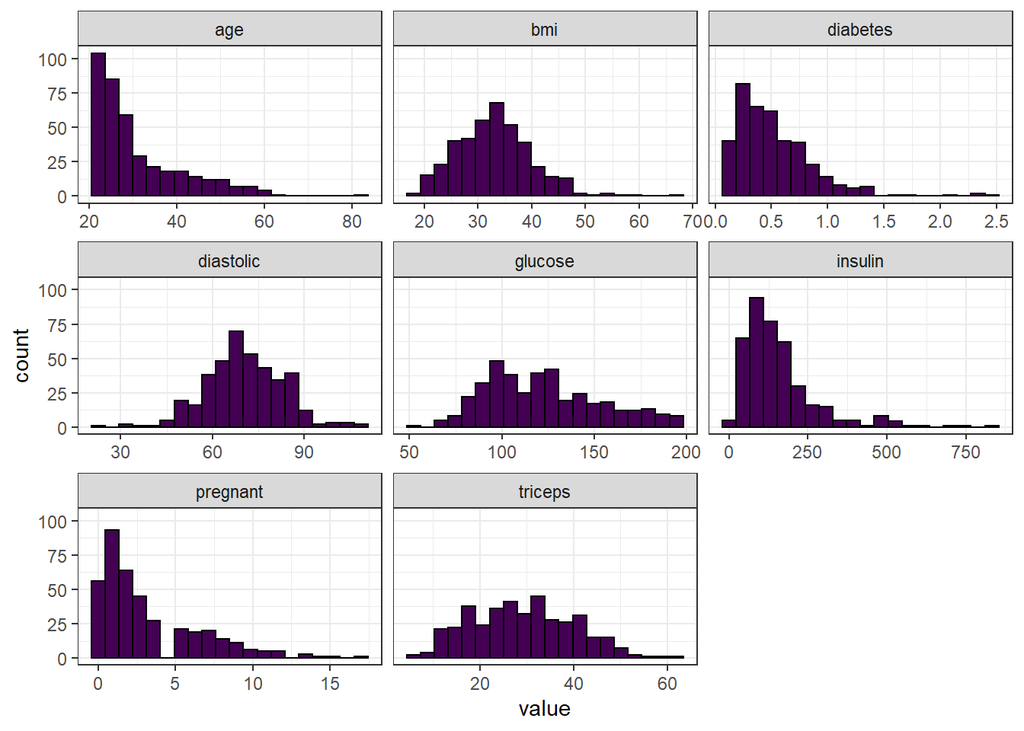

```r
ggplot(gather(pima_na[,1:8]), aes(value)) +
    geom_histogram(bins = 20, color = "black", fill = viridis(1)) +
    theme_bw() +
    facet_wrap(~key, scales = 'free_x')
```

## {.unlisted .unnumbered}

In addition to checking NA values, we may also want to explore how variables are associated with each other.

### Simple scatterplot

[figure not shown]

```r
plot(pima_na$insulin, pima_na$glucose, main = "Scatterplot of insulin and glucose",
     xlab = "Glucose level (mg/dL)",
     ylab = "Insulin level (mu U/ml)",
     pch = 16,
     col = viridis(2)[pima_na$test])
```

### Scatterplot matrix

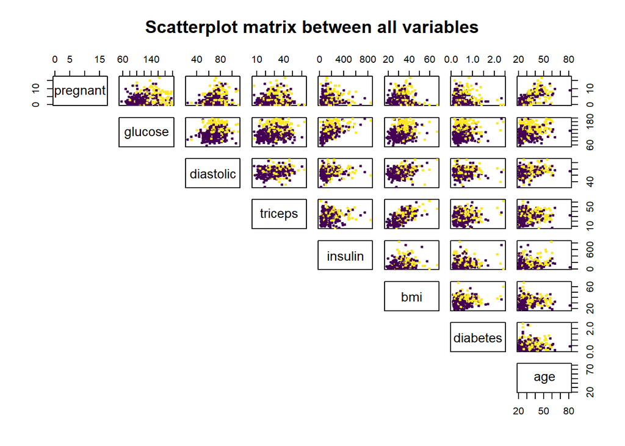

```r
pairs(pima_na[,1:8], pch = 19,  cex = 0.5,
      main = "Scatterplot matrix between all variables",
      col = viridis(2)[pima_na$test],
      lower.panel=NULL)
```

## Correlation matrix

It’s also useful to measure if there’s strong correlation between variables as they may be redundant or cause bias.

### Plot

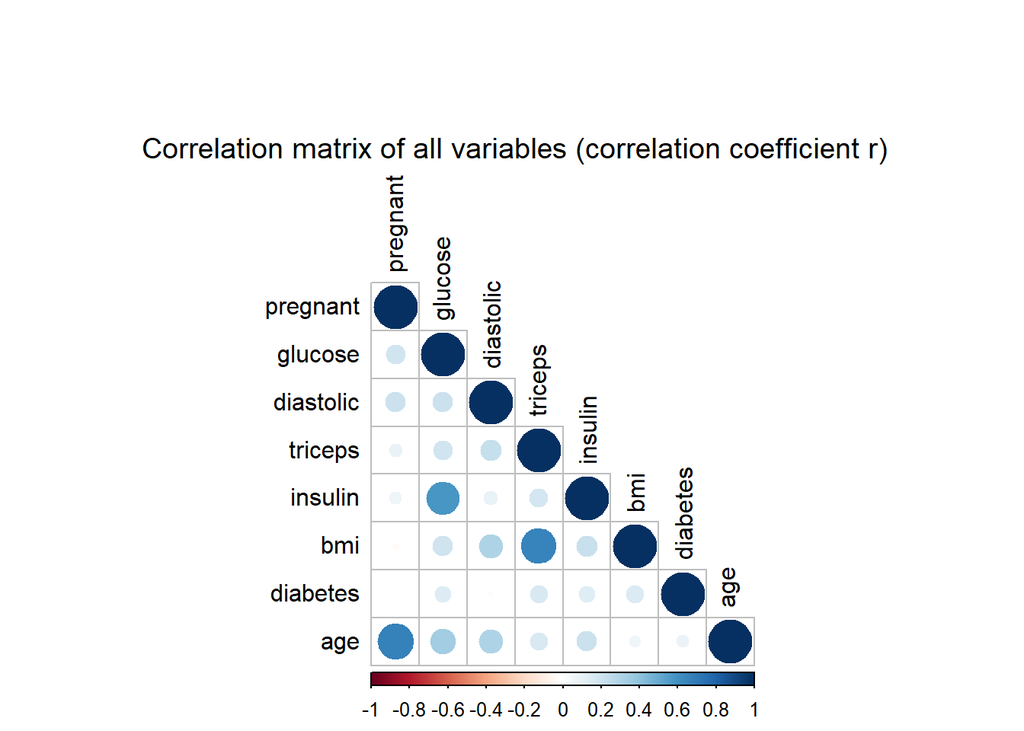

```r
pima_cor <- cor(pima_na[1:8])
corrplot(pima_cor, type = "lower", mar=c(0,0,6,0), tl.col="black")
mtext("Correlation matrix of all variables (correlation coefficient r)", at=3.5, line=-1.5, cex=1.2)
```

### Numeric

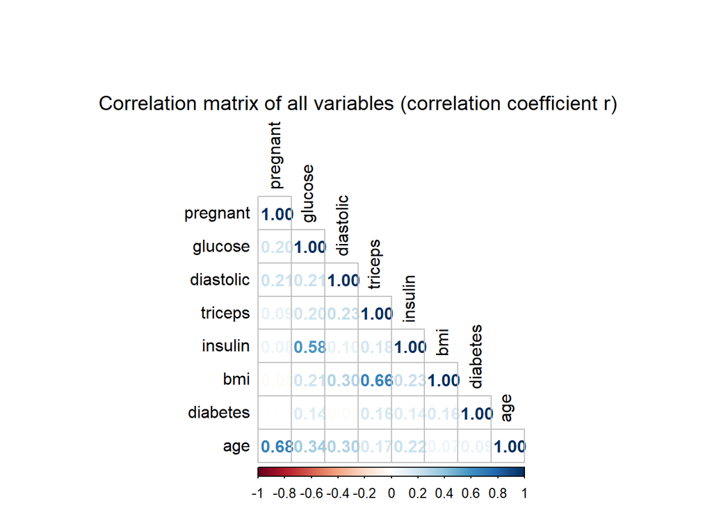

```r
corrplot(pima_cor, type = "lower", mar=c(0,0,6,0), tl.col="black",  method = "number")
mtext("Correlation matrix of all variables (correlation coefficient r)", at=3.5, line=-1.5, cex=1.2)
```

### Matrix

```r
pima_cor
```

```
##               pregnant   glucose  diastolic   triceps    insulin         bmi
## pregnant   1.000000000 0.1982910  0.2133548 0.0932094 0.07898363 -0.02534728
## glucose    0.198291043 1.0000000  0.2100266 0.1988558 0.58122301  0.20951592
## diastolic  0.213354775 0.2100266  1.0000000 0.2325712 0.09851150  0.30440337
## triceps    0.093209397 0.1988558  0.2325712 1.0000000 0.18219906  0.66435487
## insulin    0.078983625 0.5812230  0.0985115 0.1821991 1.00000000  0.22639652
## bmi       -0.025347276 0.2095159  0.3044034 0.6643549 0.22639652  1.00000000
## diabetes   0.007562116 0.1401802 -0.0159711 0.1604985 0.13590578  0.15877104
## age        0.679608470 0.3436415  0.3000389 0.1677611 0.21708199  0.06981380
##               diabetes        age
## pregnant   0.007562116 0.67960847
## glucose    0.140180180 0.34364150
## diastolic -0.015971104 0.30003895
## triceps    0.160498526 0.16776114
## insulin    0.135905781 0.21708199
## bmi        0.158771043 0.06981380
## diabetes   1.000000000 0.08502911
## age        0.085029106 1.00000000
```

## Linear Regression

### 1 continuous predictor

```r
fit1.cont <- glm(bmi ~ glucose, data =pima)
summary(fit1.cont)
```

```
##
## Call:
## glm(formula = bmi ~ glucose, data = pima)
##
## Deviance Residuals:
##     Min       1Q   Median       3Q      Max
## -32.816   -4.689   -0.225    4.592   34.666
##
## Coefficients:
##              Estimate Std. Error t value Pr(>|t|)
## (Intercept) 25.402117   1.086552  23.379  < 2e-16 ***
## glucose      0.054514   0.008689   6.274 5.89e-10 ***
## ---
## Signif. codes:  0 '***' 0.001 '**' 0.01 '*' 0.05 '.' 0.1 ' ' 1
##
## (Dispersion parameter for gaussian family taken to be 59.19926)
##
##     Null deviance: 47677  on 767  degrees of freedom
## Residual deviance: 45347  on 766  degrees of freedom
## AIC: 5317.6
##
## Number of Fisher Scoring iterations: 2
```

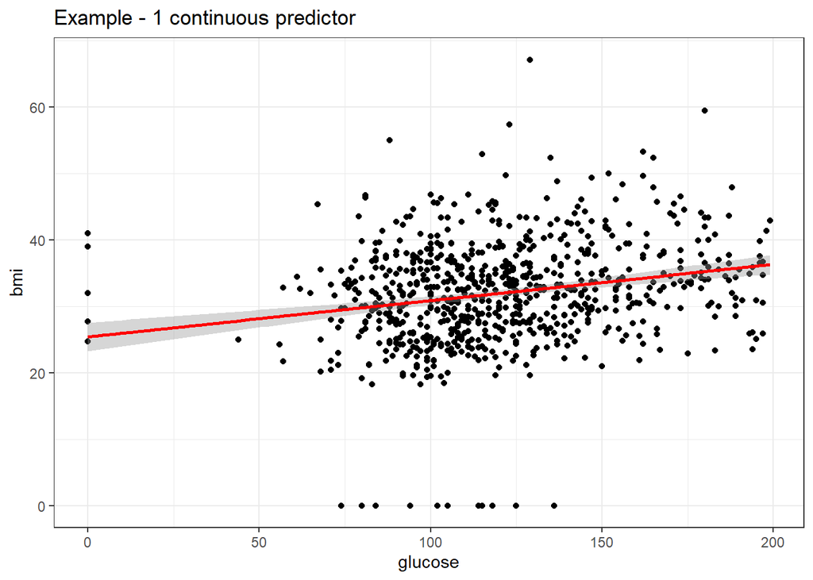

```r
ggplot(fit1.cont$model, aes_string(x = names(fit1.cont$model)[2], y = names(fit1.cont$model)[1])) +
  geom_point() +
  stat_smooth(method="glm", col = "red") +
  ggtitle("Example - 1 continuous predictor") +
  theme_bw()
```

### 2 continuous predictor

```r
fit2.cont <- glm(bmi ~ glucose + insulin, data =pima)
summary(fit2.cont)
```

```
##
## Call:
## glm(formula = bmi ~ glucose + insulin, data = pima)
##
## Deviance Residuals:
##     Min       1Q   Median       3Q      Max
## -31.956   -4.737   -0.084    4.456   34.278
##
## Coefficients:
##              Estimate Std. Error t value Pr(>|t|)
## (Intercept) 26.020657   1.089603  23.881  < 2e-16 ***
## glucose      0.043077   0.009131   4.718 2.83e-06 ***
## insulin      0.009576   0.002533   3.780 0.000169 ***
## ---
## Signif. codes:  0 '***' 0.001 '**' 0.01 '*' 0.05 '.' 0.1 ' ' 1
##
## (Dispersion parameter for gaussian family taken to be 58.18964)
##
##     Null deviance: 47677  on 767  degrees of freedom
## Residual deviance: 44515  on 765  degrees of freedom
## AIC: 5305.4
##
## Number of Fisher Scoring iterations: 2
```

```r
fit.aov <- aov(fit2.cont)
summary(fit.aov)
```

```
##              Df Sum Sq Mean Sq F value   Pr(>F)
## glucose       1   2330  2330.1   40.04 4.23e-10 ***
## insulin       1    832   831.6   14.29 0.000169 ***
## Residuals   765  44515    58.2
## ---
## Signif. codes:  0 '***' 0.001 '**' 0.01 '*' 0.05 '.' 0.1 ' ' 1
```

### 1 categorical predictor

```r
fit <- glm(bmi ~ glucose_cat, data =pima)
summary(fit)
```

```
##
## Call:
## glm(formula = bmi ~ glucose_cat, data = pima)
##
## Deviance Residuals:
##     Min       1Q   Median       3Q      Max
## -31.014   -4.814   -0.214    4.586   36.086
##
## Coefficients:
##                   Estimate Std. Error t value Pr(>|t|)
## (Intercept)        34.9271     0.5560  62.814  < 2e-16 ***
## glucose_catNormal  -3.9127     0.6421  -6.094 1.74e-09 ***
## ---
## Signif. codes:  0 '***' 0.001 '**' 0.01 '*' 0.05 '.' 0.1 ' ' 1
##
## (Dispersion parameter for gaussian family taken to be 59.3632)
##
##     Null deviance: 47677  on 767  degrees of freedom
## Residual deviance: 45472  on 766  degrees of freedom
## AIC: 5319.7
##
## Number of Fisher Scoring iterations: 2
```

```r
fit.aov <- aov(fit)
summary(fit)
```

```
##
## Call:
## glm(formula = bmi ~ glucose_cat, data = pima)
##
## Deviance Residuals:
##     Min       1Q   Median       3Q      Max
## -31.014   -4.814   -0.214    4.586   36.086
##
## Coefficients:
##                   Estimate Std. Error t value Pr(>|t|)
## (Intercept)        34.9271     0.5560  62.814  < 2e-16 ***
## glucose_catNormal  -3.9127     0.6421  -6.094 1.74e-09 ***
## ---
## Signif. codes:  0 '***' 0.001 '**' 0.01 '*' 0.05 '.' 0.1 ' ' 1
##
## (Dispersion parameter for gaussian family taken to be 59.3632)
##
##     Null deviance: 47677  on 767  degrees of freedom
## Residual deviance: 45472  on 766  degrees of freedom
## AIC: 5319.7
##
## Number of Fisher Scoring iterations: 2
```

### 2 categorical predictor

```r
fit <- glm(bmi ~ glucose_cat + insulin_cat, data =pima)
summary(fit)
```

```
##
## Call:
## glm(formula = bmi ~ glucose_cat + insulin_cat, data = pima)
##
## Deviance Residuals:
##     Min       1Q   Median       3Q      Max
## -31.982   -4.547   -0.118    4.518   35.118
##
## Coefficients:
##                   Estimate Std. Error t value Pr(>|t|)
## (Intercept)        35.2955     1.1544  30.575  < 2e-16 ***
## glucose_catNormal  -3.9822     0.7077  -5.627 2.57e-08 ***
## insulin_catLow     -1.2595     1.3351  -0.943    0.346
## insulin_catNormal   0.6685     1.3580   0.492    0.623
## ---
## Signif. codes:  0 '***' 0.001 '**' 0.01 '*' 0.05 '.' 0.1 ' ' 1
##
## (Dispersion parameter for gaussian family taken to be 58.63428)
##
##     Null deviance: 47677  on 767  degrees of freedom
## Residual deviance: 44797  on 764  degrees of freedom
## AIC: 5312.3
##
## Number of Fisher Scoring iterations: 2
```

```r
fit.aov <- aov(fit)
summary(fit)
```

```
##
## Call:
## glm(formula = bmi ~ glucose_cat + insulin_cat, data = pima)
##
## Deviance Residuals:
##     Min       1Q   Median       3Q      Max
## -31.982   -4.547   -0.118    4.518   35.118
##
## Coefficients:
##                   Estimate Std. Error t value Pr(>|t|)
## (Intercept)        35.2955     1.1544  30.575  < 2e-16 ***
## glucose_catNormal  -3.9822     0.7077  -5.627 2.57e-08 ***
## insulin_catLow     -1.2595     1.3351  -0.943    0.346
## insulin_catNormal   0.6685     1.3580   0.492    0.623
## ---
## Signif. codes:  0 '***' 0.001 '**' 0.01 '*' 0.05 '.' 0.1 ' ' 1
##
## (Dispersion parameter for gaussian family taken to be 58.63428)
##
##     Null deviance: 47677  on 767  degrees of freedom
## Residual deviance: 44797  on 764  degrees of freedom
## AIC: 5312.3
##
## Number of Fisher Scoring iterations: 2
```

## Checking model performance

### Visualizing model properties and assumptions

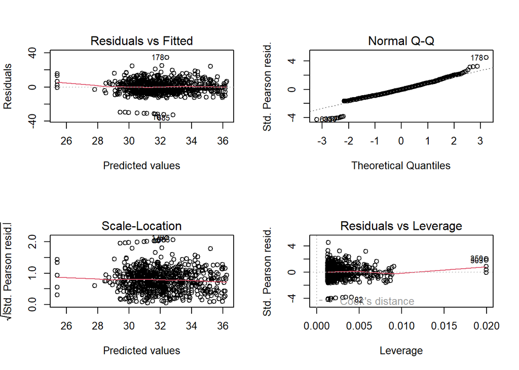

```r
par(mfrow=c(2,2)) ## show 2 by 2 plot
plot(fit1.cont)
```

```r
par(mfrow=c(1,1))   ## reset to show 1 plot at a time
```

`Residuals vs Fitted` inspects if there is curvilinear trend; residuals should be randomly distributed around zero.

`Normal Q-Q` inspects if your residuals are normally distributed i.e. should be dotted around diagonal line

`Scale-Location` similar to Residuals vs Fitted; help identify heteroskedasticity

`Residuals vs Leverage`detects outliers.

### Running one-way ANOVA

```r
fit.aov <- aov(fit1.cont)
summary(fit.aov)
```

```
##              Df Sum Sq Mean Sq F value   Pr(>F)
## glucose       1   2330  2330.1   39.36 5.89e-10 ***
## Residuals   766  45347    59.2
## ---
## Signif. codes:  0 '***' 0.001 '**' 0.01 '*' 0.05 '.' 0.1 ' ' 1
```

### Comparing two models

To compare the fit between two models, you can use `anova`. It takes two model objects as argument, and returns an ANOVA test suggesting whether one model is significantly better than another.

```r
# ANOVA
anova(fit1.cont, fit2.cont, test="Chi")
```

|  | Resid. Df | Resid. Dev | Df | Deviance | Pr(>Chi) |
| --- | --- | --- | --- | --- | --- |
| 1 | 766 | 45346.63 | NA | NA | NA |
| 2 | 765 | 44515.07 | 1 | 831.5579 | 0.0001566551 |

## Logistic Regression

Fit a model with the result of the diabetes test (binary) as the response and the other variables as predictors. Interpret the findings.

### One predictor

```r
# Fit logistic regression model from binomial family
fit <- glm(test ~ glucose,family =  binomial, pima)
summary(fit)
```

```
##
## Call:
## glm(formula = test ~ glucose, family = binomial, data = pima)
##
## Deviance Residuals:
##     Min       1Q   Median       3Q      Max
## -2.1096  -0.7837  -0.5365   0.8566   3.2726
##
## Coefficients:
##              Estimate Std. Error z value Pr(>|z|)
## (Intercept) -5.350080   0.420827  -12.71   <2e-16 ***
## glucose      0.037873   0.003252   11.65   <2e-16 ***
## ---
## Signif. codes:  0 '***' 0.001 '**' 0.01 '*' 0.05 '.' 0.1 ' ' 1
##
## (Dispersion parameter for binomial family taken to be 1)
##
##     Null deviance: 993.48  on 767  degrees of freedom
## Residual deviance: 808.72  on 766  degrees of freedom
## AIC: 812.72
##
## Number of Fisher Scoring iterations: 4
```

### Some predictors

```r
# Fit logistic regression model from binomial family
fit.some <- glm(test ~ pregnant + glucose + diastolic  + bmi,family =  binomial, pima)
summary(fit.some)
```

```
##
## Call:
## glm(formula = test ~ pregnant + glucose + diastolic + bmi, family = binomial,
##     data = pima)
##
## Deviance Residuals:
##     Min       1Q   Median       3Q      Max
## -2.2088  -0.7361  -0.4274   0.7616   2.9215
##
## Coefficients:
##              Estimate Std. Error z value Pr(>|z|)
## (Intercept) -7.657353   0.657748 -11.642  < 2e-16 ***
## pregnant     0.148535   0.027511   5.399 6.70e-08 ***
## glucose      0.034973   0.003358  10.416  < 2e-16 ***
## diastolic   -0.011921   0.005022  -2.374   0.0176 *
## bmi          0.088165   0.014074   6.264 3.74e-10 ***
## ---
## Signif. codes:  0 '***' 0.001 '**' 0.01 '*' 0.05 '.' 0.1 ' ' 1
##
## (Dispersion parameter for binomial family taken to be 1)
##
##     Null deviance: 993.48  on 767  degrees of freedom
## Residual deviance: 738.43  on 763  degrees of freedom
## AIC: 748.43
##
## Number of Fisher Scoring iterations: 5
```

### All predictor

```r
# Fit logistic regression model from binomial family
fit.all <- glm(test ~ .,family =  binomial, pima[1:9])
summary(fit.all)
```

```
##
## Call:
## glm(formula = test ~ ., family = binomial, data = pima[1:9])
##
## Deviance Residuals:
##     Min       1Q   Median       3Q      Max
## -2.5566  -0.7274  -0.4159   0.7267   2.9297
##
## Coefficients:
##               Estimate Std. Error z value Pr(>|z|)
## (Intercept) -8.4046964  0.7166359 -11.728  < 2e-16 ***
## pregnant     0.1231823  0.0320776   3.840 0.000123 ***
## glucose      0.0351637  0.0037087   9.481  < 2e-16 ***
## diastolic   -0.0132955  0.0052336  -2.540 0.011072 *
## triceps      0.0006190  0.0068994   0.090 0.928515
## insulin     -0.0011917  0.0009012  -1.322 0.186065
## bmi          0.0897010  0.0150876   5.945 2.76e-09 ***
## diabetes     0.9451797  0.2991475   3.160 0.001580 **
## age          0.0148690  0.0093348   1.593 0.111192
## ---
## Signif. codes:  0 '***' 0.001 '**' 0.01 '*' 0.05 '.' 0.1 ' ' 1
##
## (Dispersion parameter for binomial family taken to be 1)
##
##     Null deviance: 993.48  on 767  degrees of freedom
## Residual deviance: 723.45  on 759  degrees of freedom
## AIC: 741.45
##
## Number of Fisher Scoring iterations: 5
```

### Compare the logistic regressions

```r
# ANOVA
anova(fit.some, fit.all, test="Chi")
```

|  | Resid. Df | Resid. Dev | Df | Deviance | Pr(>Chi) |
| --- | --- | --- | --- | --- | --- |
| 1 | 763 | 738.4285 | NA | NA | NA |
| 2 | 759 | 723.4454 | 4 | 14.98314 | 0.004736314 |

## Example

What is the difference in the log-odds of testing positive for diabetes for a woman with a glucose level at the first quartile compared with a woman at the third quartile, assuming that all other factors are held constant? Then calculate the associated odds ratio value, and give a 95% confidence interval for this odds ratio.

```r
summary(pima_na$glucose)
```

```
##    Min. 1st Qu.  Median    Mean 3rd Qu.    Max.
##    56.0    99.0   119.0   122.6   143.0   198.0
```

```r
fit.summary <- summary(fit.all)
fit.summary
```

```
##
## Call:
## glm(formula = test ~ ., family = binomial, data = pima[1:9])
##
## Deviance Residuals:
##     Min       1Q   Median       3Q      Max
## -2.5566  -0.7274  -0.4159   0.7267   2.9297
##
## Coefficients:
##               Estimate Std. Error z value Pr(>|z|)
## (Intercept) -8.4046964  0.7166359 -11.728  < 2e-16 ***
## pregnant     0.1231823  0.0320776   3.840 0.000123 ***
## glucose      0.0351637  0.0037087   9.481  < 2e-16 ***
## diastolic   -0.0132955  0.0052336  -2.540 0.011072 *
## triceps      0.0006190  0.0068994   0.090 0.928515
## insulin     -0.0011917  0.0009012  -1.322 0.186065
## bmi          0.0897010  0.0150876   5.945 2.76e-09 ***
## diabetes     0.9451797  0.2991475   3.160 0.001580 **
## age          0.0148690  0.0093348   1.593 0.111192
## ---
## Signif. codes:  0 '***' 0.001 '**' 0.01 '*' 0.05 '.' 0.1 ' ' 1
##
## (Dispersion parameter for binomial family taken to be 1)
##
##     Null deviance: 993.48  on 767  degrees of freedom
## Residual deviance: 723.45  on 759  degrees of freedom
## AIC: 741.45
##
## Number of Fisher Scoring iterations: 5
```

```r
# Log-odds difference
LO <- coef(fit.all)["glucose"]
quart_1 <- quantile(pima_na$glucose, 0.25) # summary(pima_na$glucose)[2]
quart_3 <-  quantile(pima_na$glucose, 0.75)

diff = LO * (quart_3 - quart_1)

# Estimated log-odds ratio
exp(diff)
```

```
##  glucose
## 4.698313
```

```r
# 95% conf int for odds ratio
conf_int_odds <- cbind(diff - 1.96*fit.summary$coefficients[3,2] * (quart_3 - quart_1),
                       diff + 1.96*fit.summary$coefficients[3,2] * (quart_3 - quart_1))

# 95% conf int for estimated odds ratio
exp(conf_int_odds)
```

```
##             [,1]     [,2]
## glucose 3.412225 6.469135
```

## Exercise

1. What is the effect of BMI on diabetes status in this model (interpret the beta coefficient, log-odds, standard deviation and P-value)?
2. What is the difference in the log-odds of testing positive for diabetes for a woman with a BMI at the first quartile compared with a woman at the third quartile, assuming that all other factors are held constant?
3. Then calculate the associated odds ratio value, and give a 95% confidence interval for this odds ratio.

```r
# Insert your code here
```